# Plotting Examples

Heath Blackmon

2024-11-12

## Histogram

The histogram is an excellent plot to show distributions of data where you want to show the actual number of records in each bin.

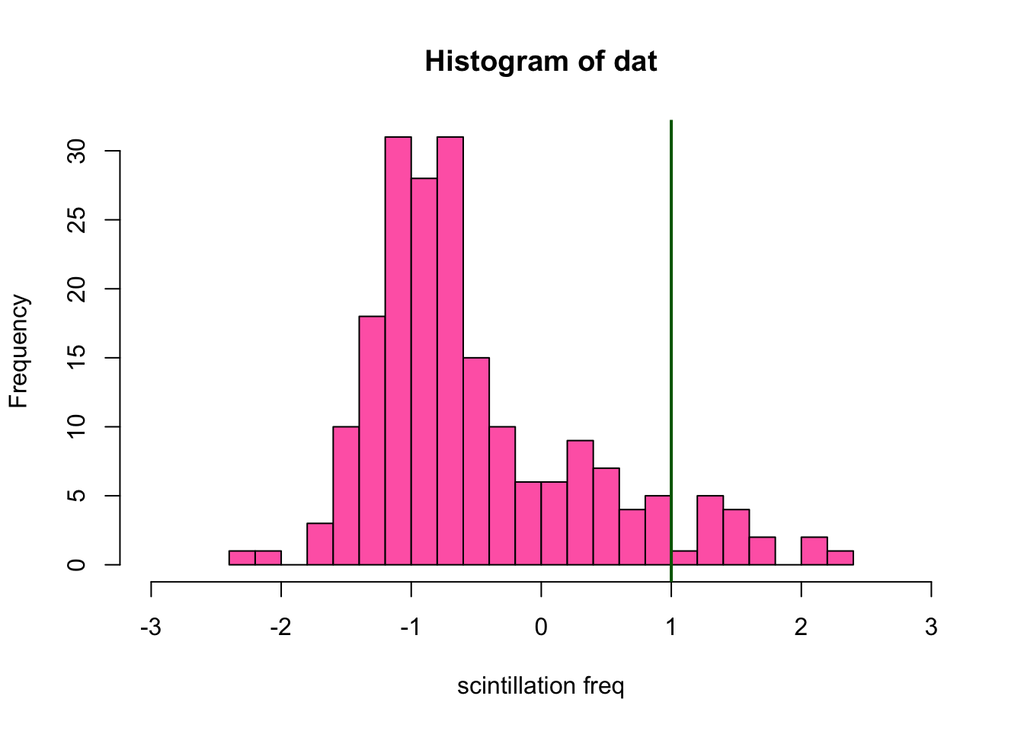

```r
# simulate a single numeric variable
dat <- c(rnorm(100),
         rnorm(100, mean = -1, sd = .3))

# make a histogram
hist(xlab = "scintillation freq",
     x = dat,
     xlim = c(-3, 3),
     breaks = 30,
     col = "hotpink")
abline(v = 1, col = "darkgreen", lwd = 2)
```

## Density Plot

Density plots are also good for visualizing distributions. I often pick a density plot if my sample size is very large 100s or 1000s of samples vs 10s of samples (when I might use a histogram instead).

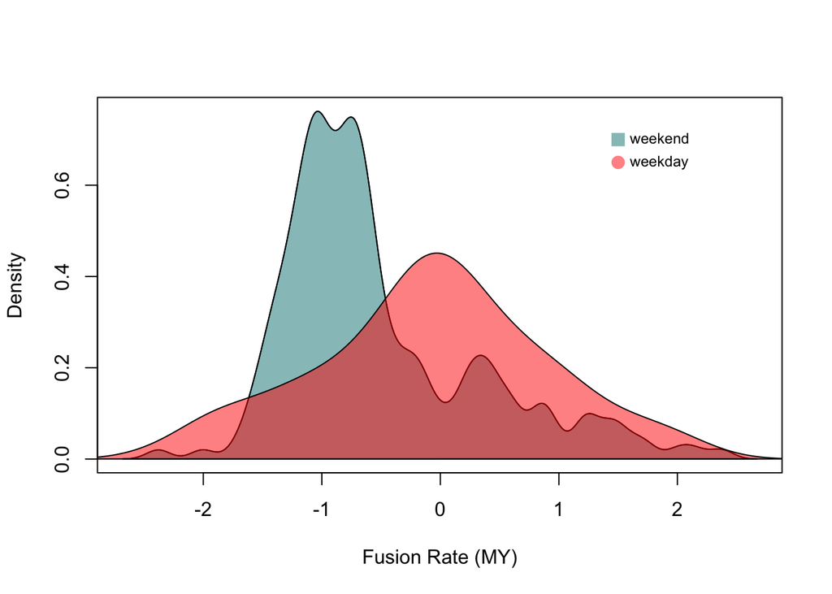

```r
# build the basic plot
plot(density(dat, bw = .1),main = "",
     xlab = "Fusion Rate (MY)")

# begin adding additional components
polygon(density(dat, bw = .1),
        col = rgb(0, .5, .5, .5))
polygon(density(rnorm(100)),
        col = rgb(1, 0, 0, .5))

# manually create a legend (compare this to the legend function)
points(x = c(1.5, 1.5),
       y = c(.7, .65), cex = 1.5,
       pch = c(15, 16), col = c(rgb(0, .5, .5, .5),
                    rgb(1, 0, 0, .5)))
text(x = c(1.5, 1.5),
       y = c(.7, .65),
       c("weekend", "weekday"), pos = 4,
     cex = .75)
```

## XY Scatter Plot

Scatter plots are good for visualizing the relationship between to continuous variables. By leveraging color or shape we can also include 1-2 additional discrete variables.

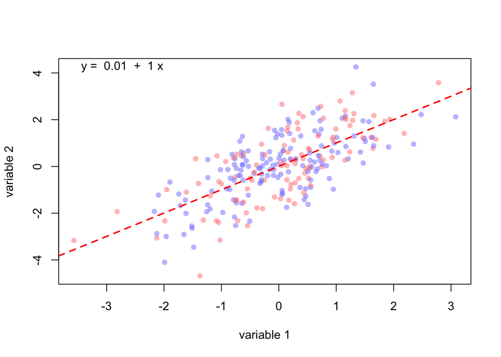

```r
# lets simulate some data
x <- rnorm(250)
y <- rnorm(250, mean = x)
sex <- as.factor(sample(c("male", "female"),
              250, replace = T))

# lets fit a linear model so we can add it to the plot too
fit <- lm(y~x)
intercept <- coef(fit)[1]
slope <- coef(fit)[2]
eq <- paste("y = ", round(intercept, 2), " + ", round(slope, 2), "x")

# create some colors to use
cols <- c(rgb(.5, .5, 1, .5),
          rgb(1, .5, .5, .5))[sex]

# make the plot
plot(y ~ x, xlab = "variable 1",
     ylab = "variable 2",
     pch = 16, col = cols)
abline(fit, lwd = 2, lty = 2, col = "red")
text(x = min(x), y = max(y), labels = eq, pos = 4)
```

## Plot for discrete predictor continuous response

Modified boxplots can be a good approach in this situation. I am a big fan of the package beeswarm that makes it easy to lay over your actual datapoints in clean and clear fashion. I load in the block of code below but to make this code work you would need to make sure you installed it first.

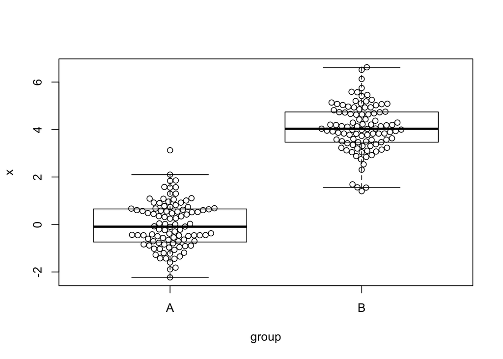

```r
# load the beeswarm package
library(beeswarm)

# lets simulate some data
x <- c(rnorm(100), rnorm(100, mean = 4))
group <- rep(c("A", "B"), each = 100)

# now lets make the plot
boxplot(x ~ group, outline = F, col = "white")
beeswarm(x ~ group, add = T)
```

Lets make another version of that with more groups and some space for significance indication.

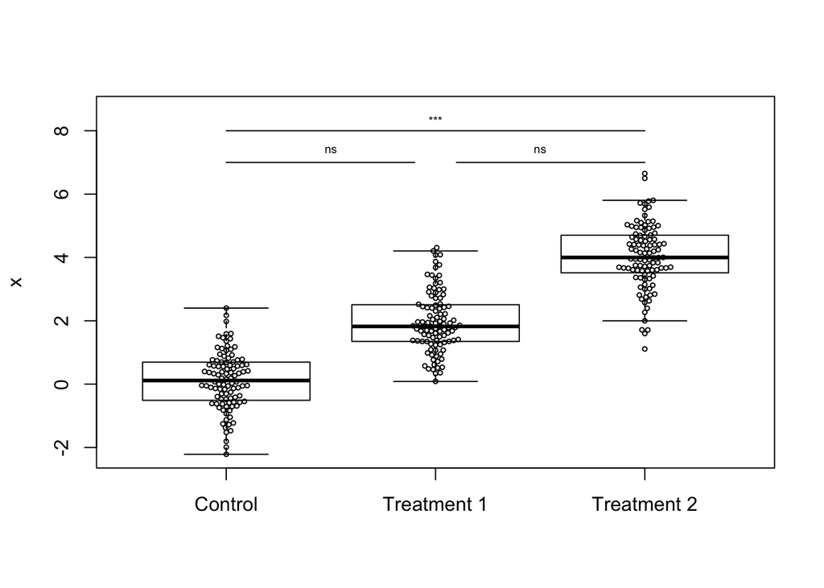

```r
# lets simulate some data. I am setting a seed here because I am going to add
# some annotation to the plot that would be hard to do if I don't know the
# precise range of the data.
set.seed(1)
x <- c(rnorm(100), rnorm(100, mean = 2), rnorm(100, mean = 4))
group <- rep(c("Control", "Treatment 1", "Treatment 2"), each = 100)

# now lets make the plot
boxplot(x ~ group, outline = F, col = "white",
        ylim = c(min(x), max(x) + 2), xlab="")
beeswarm(x ~ group, add = T, cex = .5)
lines(x = c(1, 3), y = c(8, 8))
lines(x = c(1, 1.9), y = c(7, 7))
lines(x = c(2.1, 3), y = c(7, 7))
text(2, 8.4, "***", cex = .6)
text(x = c(1.5, 2.5), y = c(7.4, 7.4), "ns", cex = .6)
```

## Plot for continuous predictor discrete response

These plots are commonly needed if you are doing logistic regressions.

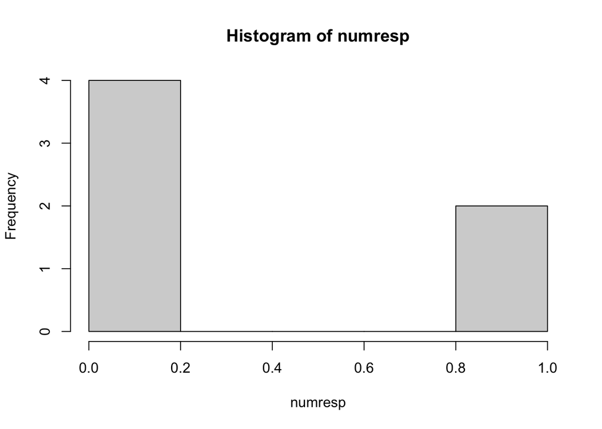

```r
# lets simulate some data
times <- runif(100, min = 0, max = 100)

# this will be our binary response variable
outcome <- rbinom(100, 1, times/100)


# typically that variable might start off more like this:
binaryresponse <- c("infected", "notinfected", "infected",
                    "infected", "notinfected", "infected")
# you would need to convert this to zeros and ones
# here is an example of one way you might do that conversion
numresp <- as.factor(binaryresponse)
numresp <- as.numeric(numresp) - 1
hist(numresp)
```

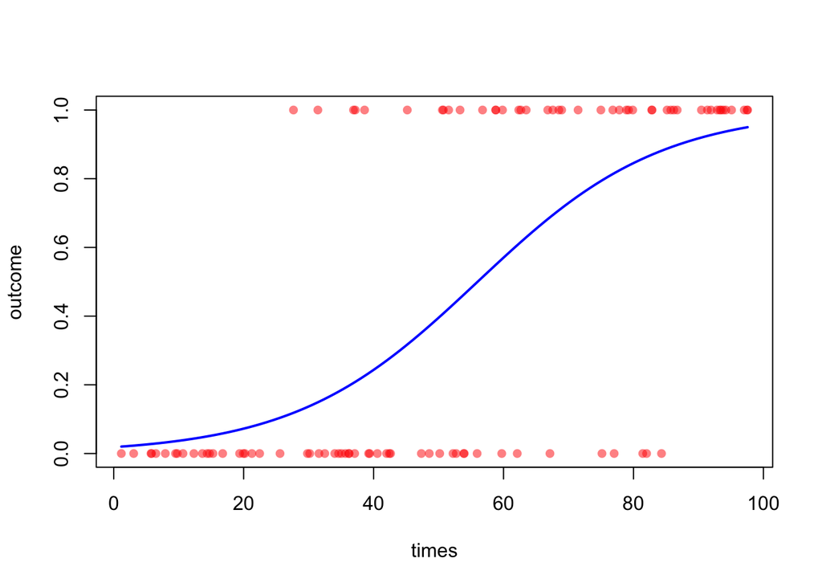

```r
# back to the example lets fit a linear regression to add to our plot
fit <- glm(outcome ~ times, family = "binomial")
# now we will generate a range of xvalues and calculate the model inffered
# probability at each point
x_vals <- seq(min(times), max(times), length.out = 100)
predicted_probs <- predict(fit, newdata = data.frame(times = x_vals), type = "response")

# now we will plot it all.
plot(outcome ~ times, pch = 16 , col = rgb(1, 0 , 0, .5))
lines(x = x_vals, y = predicted_probs, col = "blue", lwd = 2)
```